# Lab 2

Muhamad Imran Bin Maszeri

9/10/2020

```r
library(ggplot2)
choco <- read.csv("https://raw.githubusercontent.com/xdaiISU/ds202materials/master/hwlabs/data/choco.csv")
str(choco)
```

```
## 'data.frame':    2312 obs. of  13 variables:
##  $ REF                 : int  2454 2458 2454 797 797 1015 1019 1011 1019 1011 ...
##  $ Company             : chr  "5150" "5150" "5150" "A. Morin" ...
##  $ Location            : chr  "U.S.A." "U.S.A." "U.S.A." "France" ...
##  $ Date                : int  2019 2019 2019 2012 2012 2013 2013 2013 2013 2013 ...
##  $ Bean_Origin         : chr  "Madagascar" "Dominican Republic" "Tanzania" "Peru" ...
##  $ Specific_Bean_Origin: chr  "Bejofo Estate, batch 1" "Zorzal, batch 1" "Kokoa Kamili, batch 1" "Peru" ...
##  $ Cocoa_Percent       : num  76 76 76 63 70 70 63 70 70 70 ...
##  $ Ingredients         : chr  "3- B,S,C" "3- B,S,C" "3- B,S,C" "4- B,S,C,L" ...
##  $ Characteristics1    : chr  "cocoa" "cocoa" "rich cocoa" "fruity" ...
##  $ Characteristics2    : chr  "blackberry" "vegetal" "fatty" "melon" ...
##  $ Characteristics3    : chr  "full body" "savory" "bready" "roasty" ...
##  $ Characteristics4    : chr  NA NA NA NA ...
##  $ Rating              : num  3.75 3.5 3.25 3.75 3.5 4 4 3.75 3.5 3.25 ...
```

1. How are the ratings distributed? Create both a histogram and a boxplot and describe them. Don’t forget to mention outliers, if there are any.

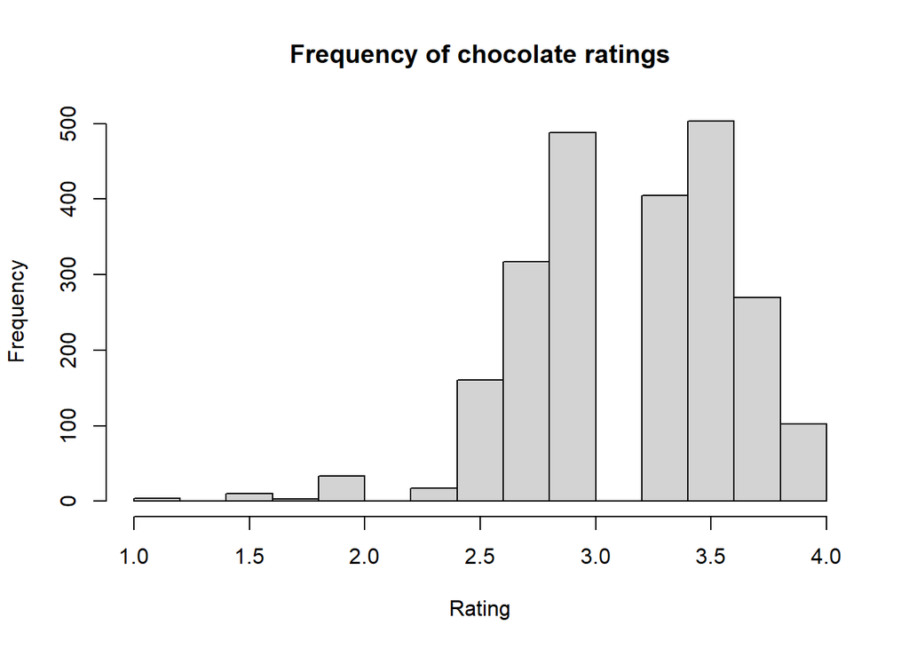

```r
hist(choco$Rating, main="Frequency of chocolate ratings", xlab="Rating")
```

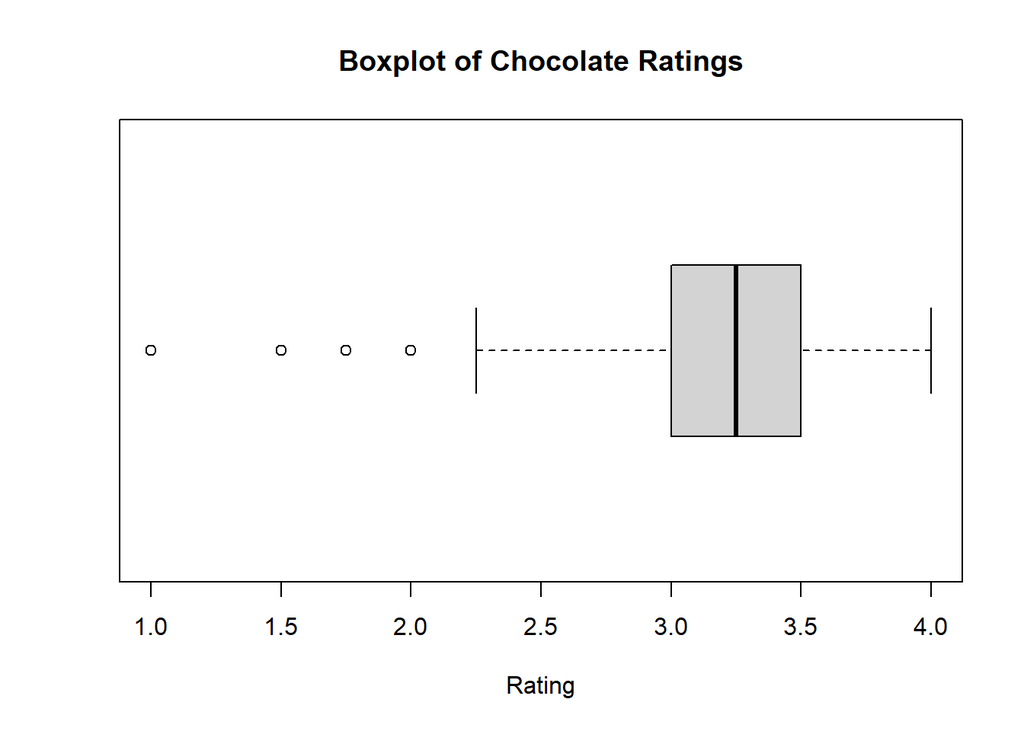

```r
boxplot(choco$Rating, main="Boxplot of Chocolate Ratings", xlab="Rating", horizontal=TRUE)
```

Answer: The histogram shows that the graph is left skewed towards “Outstanding” Rating. The boxplot shows that the mean of the rating is somewhere between 3.0 and 3.5, which shows that the ratings of the chocolates are generally favorable from recommended to outstanding. The min of the rating is around 2.0 to 2.5. Ratings that are below 2.0 are generally considered outliers, so there are not many unpleasant chocolates in this graph

2. How does the number of ratings depend on the year? Draw a bar chart of the number of reports.

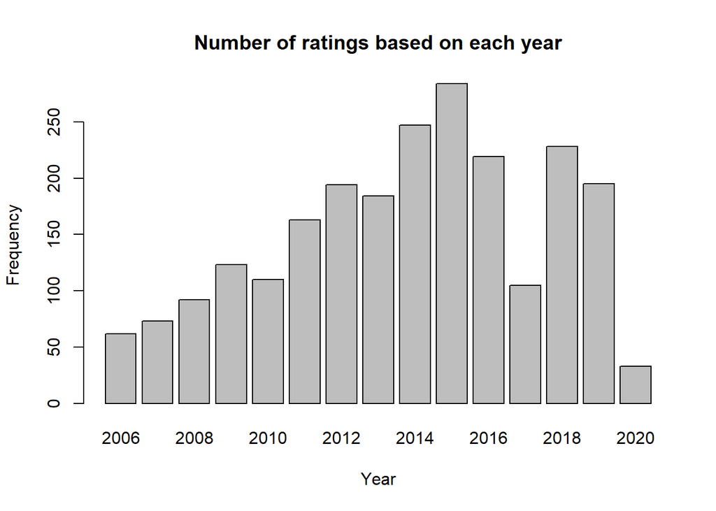

```r
barplot(table(choco$Date), main="Number of ratings based on each year",
        xlab="Year", ylab="Frequency")
```

Answer: As the year progresses, there are more occurences of ratings, with the frequency peaked at 2015. Somehow, the number of ratings dropped massively in 2017 before rising again

3. Do ratings depend on the cacao percentage of a chocolate bar? Create both numerical and graphical summaries, and explain.

```r
outs <- choco[(choco$Rating >= 4.0) & (choco$Rating <= 5.0), ]
highrec <- choco[(choco$Rating >= 3.5) & (choco$Rating <= 3.9), ]
rec <- choco[(choco$Rating >= 3.0) & (choco$Rating <= 3.49), ]
dis <- choco[(choco$Rating >= 2.0) & (choco$Rating <= 2.9), ]
unp <- choco[(choco$Rating >= 1.0) & (choco$Rating <= 1.9), ]

totalmean <- c(mean(outs$Cocoa_Percent), mean(highrec$Cocoa_Percent),
               mean(rec$Cocoa_Percent), mean(dis$Cocoa_Percent),
               mean(unp$Cocoa_Percent))
names(totalmean) <- c("Outs", "HighRec", "Rec",
                      "Dis", "Unp")
totalmean
```

```
##     Outs  HighRec      Rec      Dis      Unp
## 70.77451 71.12549 71.56327 72.31784 84.29412
```

```r
cor(choco$Rating, choco$Cocoa_Percent)
```

```
## [1] -0.1510178
```

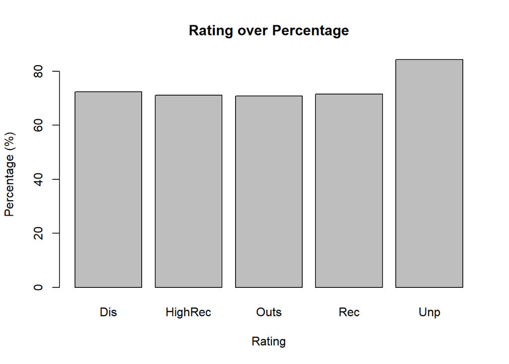

```r
barplot(totalmean ~ names(totalmean), main="Rating over Percentage",
        xlab="Rating", ylab="Percentage (%)")
```

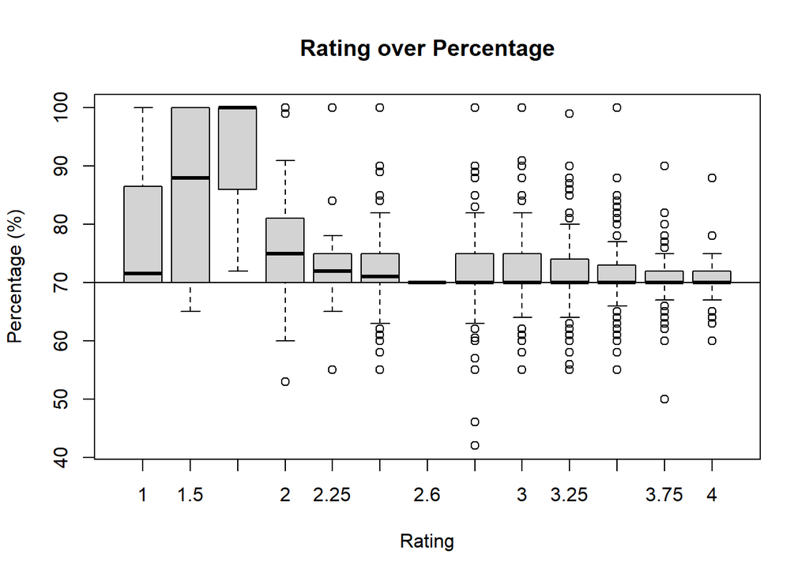

```r
boxplot(choco$Cocoa_Percent ~ choco$Rating, main="Rating over Percentage",
        xlab="Rating", ylab="Percentage (%)")
abline(h=70)
```

Answer: Using correlation, it seems that there is somewhat a little to no negative linear relationship between ratings and percentage, with the value of -0.1. Next, the barchart shows that the “Unpleasant” ranking range has the highest average of percentage, with the value of 84.3%. Using boxplot, it can be seen that as the rating increases, the mean value of percentage is closer to 70%.

4. How do different characteristics of the chocolate compare? To elaborate, which characteristics tend to be more favorable and which ones are not? Create both numerical and graphical summaries, and explain.

```r
fav <- choco[(choco$Rating >= 3.0) & (choco$Rating <= 5.0), ]
ftable <- sort(table(fav$Characteristics1), decreasing = TRUE)
head(ftable)
```

```
##
##  creamy   sandy intense   nutty   sweet   fatty
##     148      98      64      63      53      49
```

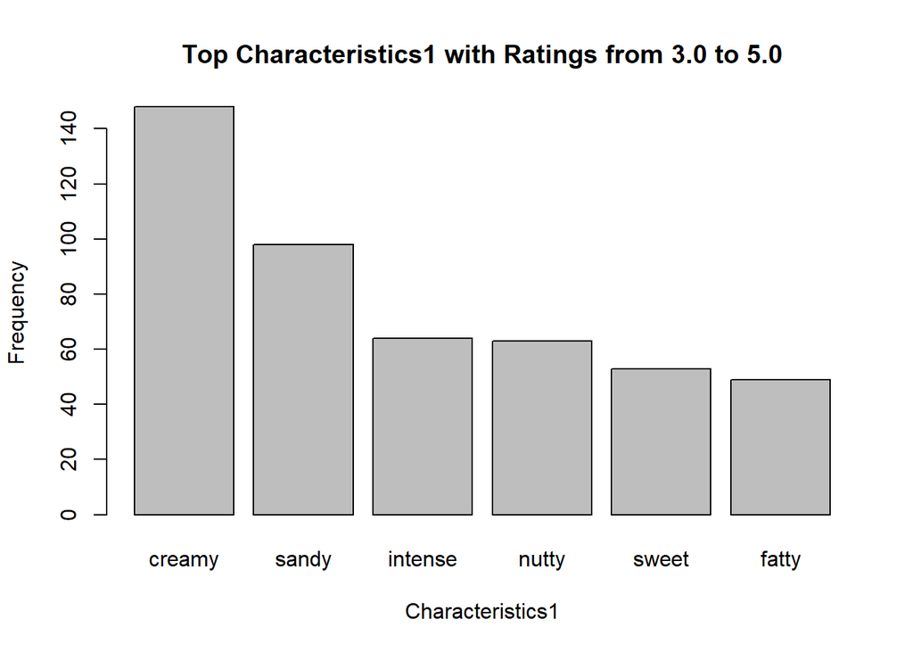

```r
barplot(head(ftable), main="Top Characteristics1 with Ratings from 3.0 to 5.0",
        xlab="Characteristics1", ylab="Frequency")
```

```r
fav2 <- choco[(choco$Rating >= 3.0) & (choco$Rating <= 5.0), ]
ftable2 <- sort(table(fav$Characteristics2), decreasing = TRUE)
head(ftable2)
```

```
##
##  sweet  nutty  cocoa roasty earthy floral
##     79     74     59     54     47     46
```

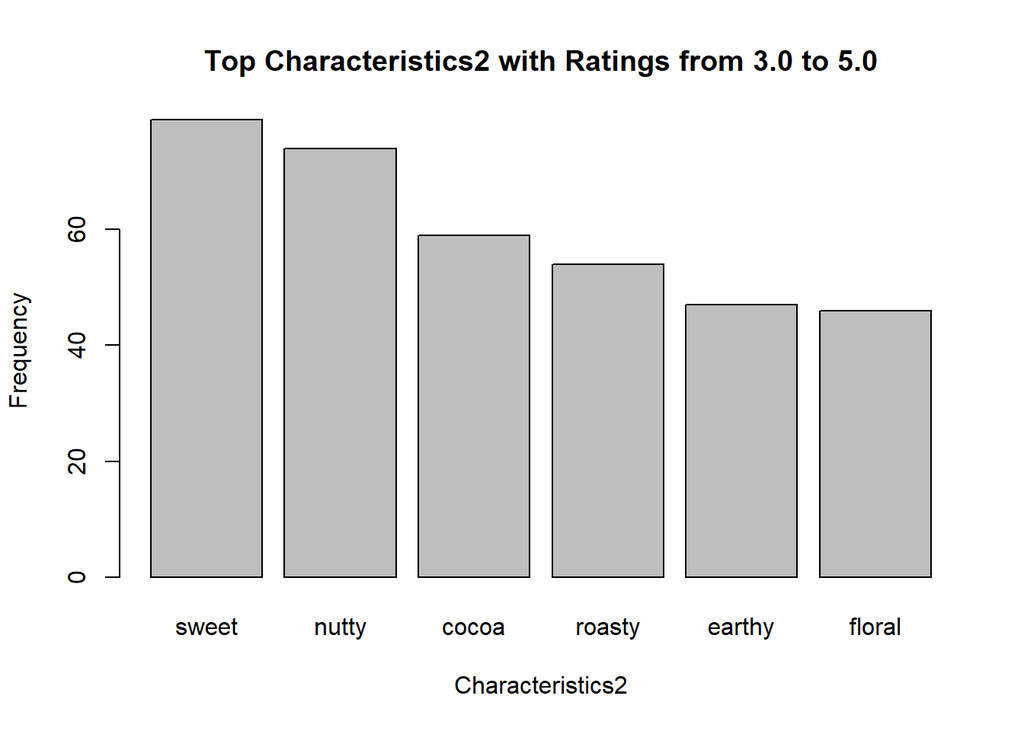

```r
barplot(head(ftable2), main="Top Characteristics2 with Ratings from 3.0 to 5.0",
        xlab="Characteristics2", ylab="Frequency")
```

```r
fav3 <- choco[(choco$Rating >= 3.0) & (choco$Rating <= 5.0), ]
ftable3 <- sort(table(fav$Characteristics3), decreasing = TRUE)
head(ftable3)
```

```
##
##  cocoa  nutty roasty   sour  sweet coffee
##     90     59     57     42     36     33
```

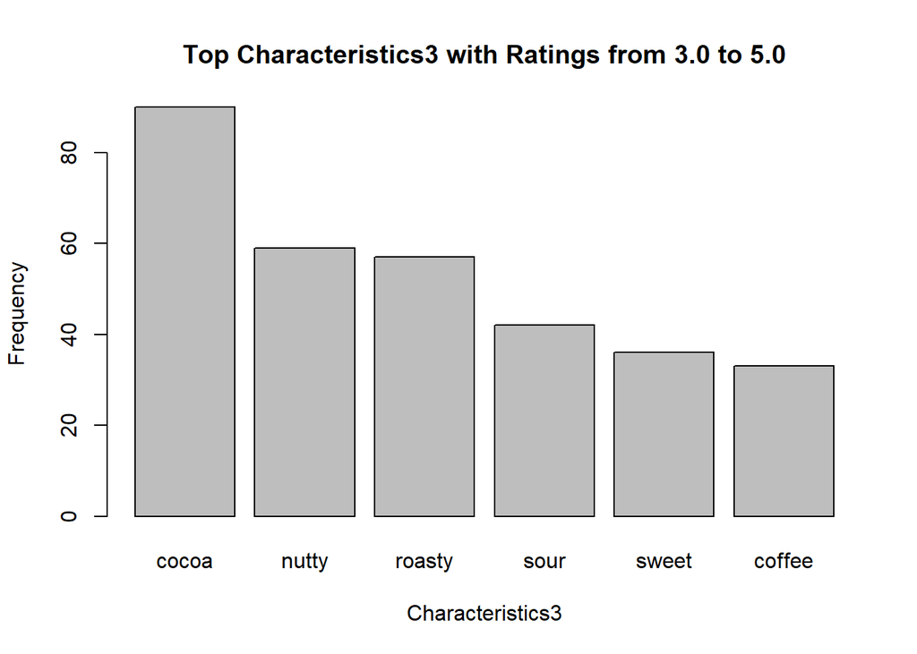

```r
barplot(head(ftable3), main="Top Characteristics3 with Ratings from 3.0 to 5.0",
        xlab="Characteristics3", ylab="Frequency")
```

```r
unfav <- choco[(choco$Rating >= 1.0) & (choco$Rating <= 2.9), ]
utable <- sort(table(unfav$Characteristics1), decreasing = TRUE)
head(utable)
```

```
##
##  sandy gritty  fatty    dry  sweet sticky
##     36     28     27     23     21     20
```

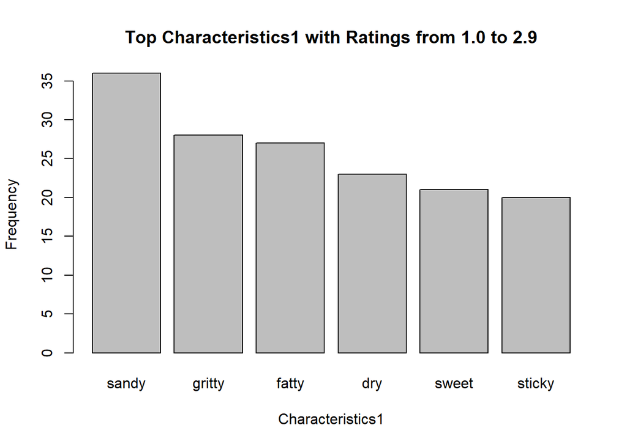

```r
barplot(head(utable), main="Top Characteristics1 with Ratings from 1.0 to 2.9",
        xlab="Characteristics1", ylab="Frequency")
```

```r
unfav2 <- choco[(choco$Rating >= 1.0) & (choco$Rating <= 2.9), ]
utable2 <- sort(table(unfav$Characteristics2), decreasing = TRUE)
head(utable2)
```

```
##
##    sweet   earthy  vanilla     sour   floral molasses
##       41       28       25       17       14       14
```

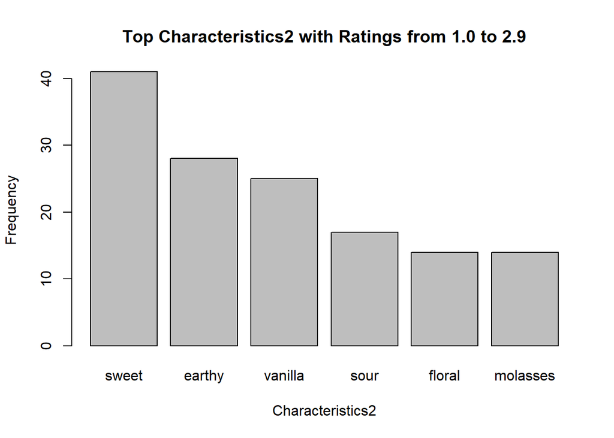

```r
barplot(head(utable2), main="Top Characteristics2 with Ratings from 1.0 to 2.9",
        xlab="Characteristics2", ylab="Frequency")
```

```r
unfav3 <- choco[(choco$Rating >= 1.0) & (choco$Rating <= 2.9), ]
utable3 <- sort(table(unfav$Characteristics3), decreasing = TRUE)
head(utable3)
```

```
##
##   sour earthy bitter roasty  nutty  sweet
##     23     19     18     13     12     12
```

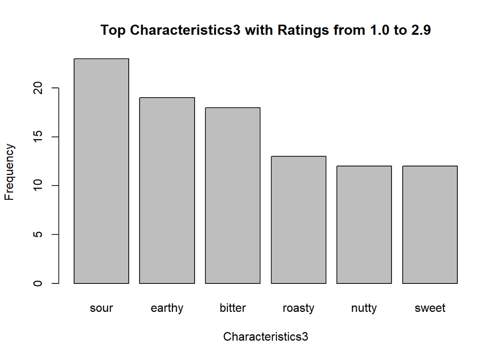

```r
barplot(head(utable3), main="Top Characteristics3 with Ratings from 1.0 to 2.9",
        xlab="Characteristics3", ylab="Frequency")
```